# Is Karlsruhe Getting Sunnier?

Annual sunshine hours since the 1930s

Author

Solution to the c03 Try-it

Published

November 20, 2026

## 1 Question and data

Sunshine matters for agriculture, solar power and health, and it isn’t constant: across Europe, sunshine at the surface fell from the 1950s to the 1980s and has risen since, a pattern known as “dimming” and “brightening” (Wild 2009). Does Karlsruhe show it too?

The data are daily sunshine hours from the Deutscher Wetterdienst (Deutscher Wetterdienst 2026), from the Karlsruhe station until 2008 and from Rheinstetten since, analysed with the tidyverse (Wickham et al. 2023). Sunshine was measured from 1936 on. We only keep years with at least 360 measured days.

## 2 Results

Figure 1 shows the annual sunshine hours. After a dip to the 1970s, the trend points clearly upwards: in 1996–2025, Karlsruhe had 166 more hours of sunshine per year than in the reference period 1961–1990 (1691 hours).

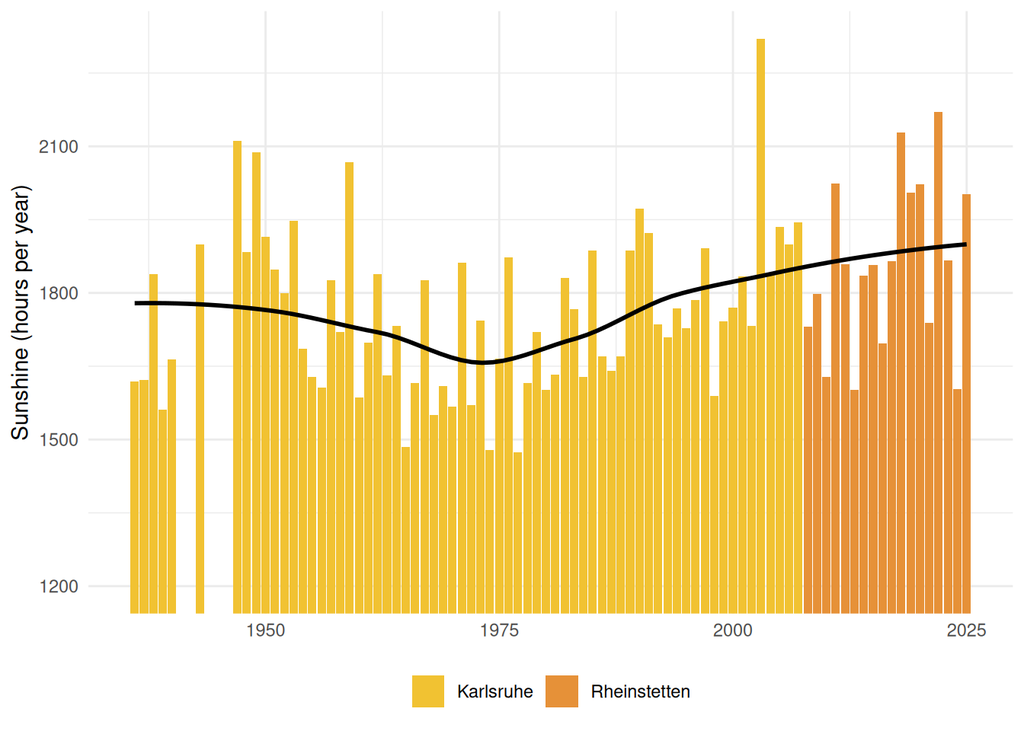

Figure 1: Annual sunshine hours, with a smoothed trend.

Table 1 gives the averages per decade.

Table 1: Average annual sunshine hours per decade (complete years only).

| Decade | Sunshine (hours) | Years |
| --- | --- | --- |
| 1930s | 1660 | 4 |
| 1940s | 1929 | 5 |
| 1950s | 1804 | 10 |
| 1960s | 1657 | 10 |
| 1970s | 1657 | 10 |
| 1980s | 1721 | 10 |
| 1990s | 1784 | 10 |
| 2000s | 1881 | 10 |
| 2010s | 1850 | 10 |
| 2020s | 1901 | 6 |

## 3 Conclusion

Yes: Karlsruhe has been getting sunnier since the 1980s, after a darker period in the 1960s and 1970s, in line with the European dimming and brightening. One caveat: the series switches from the Karlsruhe to the Rheinstetten station in 2008, so part of a difference across that year could come from the change of location.

## References

Deutscher Wetterdienst. 2026. *Historical Daily Station Observations (Temperature, Pressure, Precipitation, Sunshine Duration, Etc.) for Germany*. Climate Data Center. https://opendata.dwd.de/climate_environment/CDC/observations_germany/climate/daily/kl/historical/.

Wickham, Hadley, Mine Çetinkaya-Rundel, and Garrett Grolemund. 2023. *R for Data Science*. 2nd ed. O’Reilly. https://r4ds.hadley.nz/.

Wild, Martin. 2009. “Global Dimming and Brightening: A Review.” *Journal of Geophysical Research: Atmospheres* 114: D00D16. https://doi.org/10.1029/2008JD011470.